# 일반화선형모형 : Generalized linear model III

선형모형, 로지스틱모형, count regression 등에 이르기까지 다양한 종류의 response를 (1) response 자체의 분포의 특성을 고려하여 (2) conditional mean function을 추정하기 위한 적절한 연결함수를 고려하여 모형화 및 추정을 시도하였다.

이러한 것들을 보다 일반화하여 앞서 다루었던 모형 및 추정법등을 포함하는 하나의 모형을 생각할 수 있는데 이를 일반화선형모형 (Generalized linear model : GLM)이라 한다.

# 1 GLM definition

GLM은 크게 두 가지 요소를 특정하는 것으로 정의된. 첫째 response의 분포로, 기본적으로 지수족 (exponential family)을 따르는 것으로 가정한다. 둘째는 link 함수로, response의 conditional mean function을 linear predictor와 어떻게 연결할 것인지이다.

## 1.1 Exponential family : 다음과 같은 분포를 따를 때 $Y$가 지수족을 따른다고 한다.

$$f(y|\theta,\phi) = \exp\left[ \frac{y\theta - b(\theta)}{a(\phi)} + c(y,\phi) \right]$$

$\theta$ : canonical parameter, $\phi$ : dispersion parameter

1. 정규분포 ($N(\mu.\sigma^2)$) :
   $$\theta = \mu, ~\phi = \sigma^2, ~a(\phi)=\phi,~ b(\theta)=\theta^2 / 2,~ c(y,\phi) = -(y^2/\phi + \log(2\pi\phi))/2$$
2. Poisson :

$$\theta = \log(\mu),~\phi=1,~a(\phi) = 1,~b(\theta)=\exp(\theta),~c(y,phi)=-\log y!$$

3. Binomial :

$$\theta = \log(\mu/(1-\mu)),~b(\theta)=-n\log(1-\mu)=n\log(1+\exp(\theta)),~c(y,phi)=\log{{n}\choose{y}}$$

감마 및 역감마분포도 지수족에 포함된다.

일반적으로 지수족을 따르는 경우 response의 평균과 분산이 어떻게 표현되는지는 다음으로부터 이끌어 낼 수 있다.

먼저 log-likelihood for a sigle $y$는 다음과 같이 주어지므로:

$$l(\theta)=(y\theta-b(\theta))/a(\phi) + c(y,\phi)$$

이 함수의 일차/이차 미분은 다음과 같이 계산된다.

$$l'(\theta) =(y-b'(\theta))/a(\phi),~l''(\theta)=-b''(\theta)/a(\phi)$$

그러면 score function 이 mean이 0이라는 성질과 이차미분에 대한 성질로부터 ;

$El'(\theta)=0$과 $El''(\theta)=-E[l'(\theta)^2]$를 얻고 이로부터 다음 식을 얻을 수 있다.

$$E(Y)=\mu=b'(\theta),~Var(Y)=b''(\theta)a(\phi)$$

위로부터 평균은 $\theta$이 함수임을 알 수 있다. 또한 분산은 $\theta$와 $\phi$의 함수의 곱 형태로 주어진다. 여기서 $V(\mu)=b''(\theta)/w$를 variance function이라 지칭하는데 이는 분산이 평균과 어떻게 연결되는지를 기술해주는 것으로 이해할 수 있다.

## 1.2 Link function

정준연결함수 $g$는 $\eta=g(\mu)=\theta$를 만족하는 함수를 말한다. 이는 곧 $g(b'(\theta))=\theta$를 함의하게 된다. Poisson 분포에서는 log함수가 Binomial 분포에서는 logit 함수가 정규분포에서는 항등함수가 정준연결함수가 됨이 알려져 있다.

이러한 정준연결함수는 수학적으로 또한 추정량 계산상에 있어서 여러가지 장점이 있어 널리 쓰인다.

# 2 Fitting a GLM

최대가능도추정법이 GLM의 추정에서 기본적으로 쓰인다. 분포가 정규분포일 때를 제외하면 가능도방정식의 해가 명시적으로 표현되지 않기 때문에 수치적인 접근법을 이용해야 한다. 보통 Newton-Raphson에 근거한 방법들을 이용하게 된다.

# 3 Hypothesis tests

- Null model : 가장 간단한 모형으로 설명변수가 하나도 포함되지 않은 모형
- Full (Saturated) model :가장 복잡하고 큰 모형으로 $n$개의 관측치에 대하여 $n$개의 parameter를 사용. 이 경우 $\hat\mu = y$가 만족되게 된다.

앞서 언급했듯이 현재 모형이 데이터를 얼마나 잘 적합하는지를 측정하고 할 때, 현재 모형을 full model과 비교하게 된다. 즉, 다음과 같은 두 모형의 차이를 생각한다.

$$2[ \log(y,\phi|y) - \log(\hat\mu,\phi|) ]$$

이를 deviance라 하고 다음과 같이 쓴다.

$$D(y,\hat\mu) .$$

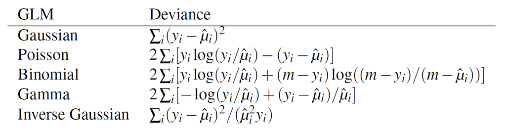

이는 선형모형에거 SSE를 GLM 하에서 일반화시킨 것으로 간주할 수 있다.

적합도를 측정하는 또 다른 방법 중 하나는 Pearson’s $X^2$ 통계량을 고려하는 것이다.

$$X^2 = \sum_i \frac{(y_i - \hat\mu_i)^2}{V(\hat\mu_i)}$$

더 큰 모형을 $\Omega$ 작은 모형을 $\omega$라 할 때, scaled deviance의 차이 $D_\omega - D_\Omega$는 점근적으로 $\chi^2$ 분포를 따르게 된다. 이 때 자유도는 두 모형의 모수 개수의 차이이다.

```r
library(faraway)
data(bliss, package="faraway")
modl <- glm(cbind(dead,alive) ~ conc, family=binomial, bliss)
summary(modl)
```

```
##
## Call:
## glm(formula = cbind(dead, alive) ~ conc, family = binomial, data = bliss)
##
## Deviance Residuals:
##       1        2        3        4        5
## -0.4510   0.3597   0.0000   0.0643  -0.2045
##
## Coefficients:
##             Estimate Std. Error z value Pr(>|z|)
## (Intercept)  -2.3238     0.4179  -5.561 2.69e-08 ***
## conc          1.1619     0.1814   6.405 1.51e-10 ***
## ---
## Signif. codes:  0 '***' 0.001 '**' 0.01 '*' 0.05 '.' 0.1 ' ' 1
##
## (Dispersion parameter for binomial family taken to be 1)
##
##     Null deviance: 64.76327  on 4  degrees of freedom
## Residual deviance:  0.37875  on 3  degrees of freedom
## AIC: 20.854
##
## Number of Fisher Scoring iterations: 4
```

```r
1-pchisq(deviance(modl),df.residual(modl))  # test for goodness of fit
```

```
## [1] 0.9445968
```

```r
modl2 <- glm(cbind(dead,alive) ~ conc+I(conc^2), family=binomial, bliss)
anova(modl,modl2,test="Chi")   # test for additional parameter
```

```
## Analysis of Deviance Table
##
## Model 1: cbind(dead, alive) ~ conc
## Model 2: cbind(dead, alive) ~ conc + I(conc^2)
##   Resid. Df Resid. Dev Df Deviance Pr(>Chi)
## 1         3    0.37875
## 2         2    0.19549  1  0.18325   0.6686
```

```r
anova(modl2,test="Chi")        # test for additional parameter
```

```
## Analysis of Deviance Table
##
## Model: binomial, link: logit
##
## Response: cbind(dead, alive)
##
## Terms added sequentially (first to last)
##
##
##           Df Deviance Resid. Df Resid. Dev  Pr(>Chi)
## NULL                          4     64.763
## conc       1   64.385         3      0.379 1.024e-15 ***
## I(conc^2)  1    0.183         2      0.195    0.6686
## ---
## Signif. codes:  0 '***' 0.001 '**' 0.01 '*' 0.05 '.' 0.1 ' ' 1
```

# 4 GLM Diagnostics

선형모형에서 잔차를 중심으로 모형진단을 했듯이 GLM에서도 비슷한 절차가 필요할 수 있다.

## 4.1 Residuals

잔차는 response 상에서 관측치와 모형에 의한 적합치 사이의 차이를 의미한다. 선형모형에서 정의했던 것을 확장하여 잔차를 GLM에서 정의하기도 한다.

### 4.1.1 Pearson residual

선형모형에서의 표준화잔차와 유사한 개념으로 이해할 수 있다.

$$r_P = \frac{y-\hat\mu}{\sqrt{V(\hat\mu)}}$$

여기서 $V(\mu) = b''(\theta)$이다. 또한 $\sum r_P^2 = X^2$가 된다.

### 4.1.2 Deviance residual

Deviance로부터 정의되는 타입의 잔차이다.

$$\sum r_D^2 = Deviance = \sum d_i$$

따라서

$$r_D = sign(y-\hat\mu)\sqrt{d_i}$$

```r
residuals(modl)     # deviance residual
```

```
##           1           2           3           4           5
## -0.45101510  0.35969607  0.00000000  0.06430235 -0.20449347
```

```r
residuals(modl,"pearson") # Pearson residual
```

```
##             1             2             3             4             5
## -4.325234e-01  3.643729e-01 -3.648565e-15  6.414687e-02 -2.081068e-01
```

```r
residuals(modl,"response") # response residual
```

```
##             1             2             3             4             5
## -2.250510e-02  2.834353e-02 -3.330669e-16  4.989802e-03 -1.082823e-02
```

```r
bliss$dead/30 - fitted(modl)
```

```
##             1             2             3             4             5
## -2.250510e-02  2.834353e-02 -3.330669e-16  4.989802e-03 -1.082823e-02
```

QQ plot은 선형모형에서 정규성을 확인하기 위해 사용하는 시각화 방법 중 하나였다. GLM에서는 분포 자체를 확인하기 위한 목적보다는 이상점의 존재를 확인하기 위한 목적으로 보통 활용된다.